# iris-data-ml-class

```python
# This Python 3 environment comes with many helpful analytics libraries installed
# It is defined by the kaggle/python Docker image: https://github.com/kaggle/docker-python
# For example, here's several helpful packages to load

import numpy as np # linear algebra
import pandas as pd # data processing, CSV file I/O (e.g. pd.read_csv)

# Input data files are available in the read-only "../input/" directory
# For example, running this (by clicking run or pressing Shift+Enter) will list all files under the input directory

import os
for dirname, _, filenames in os.walk('/kaggle/input'):
    for filename in filenames:
        print(os.path.join(dirname, filename))

# You can write up to 20GB to the current directory (/kaggle/working/) that gets preserved as output when you create a version using "Save & Run All"
# You can also write temporary files to /kaggle/temp/, but they won't be saved outside of the current session
```

```python
from sklearn.datasets import load_iris
```

```python
iris_data = load_iris()
iris_data
```

[output not shown]

[output cut: 111 more lines]

[output not shown]

```python
# iris_data의 key값 확인하기
type(iris_data)
```

```
sklearn.utils.Bunch
```

## data 파악하기

- Bunch 클래스는 python 딕셔너리와 유사하다
- key 값을 확인해 보자 : iris_data.keys()
- iris 꽃은 유사한 3종류를 나누어 놓았다. setosa, versicolor, virginica
- data : sepal length(꽃받침 길이), sepal width(꽃받침 너비), petal length(꽃잎 길이), petal width(꽃잎 너비)의 값
- target : setosa=0, versicolor=1, virginica=2 로 표시
- target_name : setosa, versicolor, virginica
- DESCR : 파일설명
- feature_names : sepal length(꽃받침 길이), sepal width(꽃받침 너비), petal length(꽃잎 길이), petal width(꽃잎 너비)
- filename : iris.csv
- data_module : sklearn.datasets.data

```python
keys = iris_data.keys()
keys
```

```
dict_keys(['data', 'target', 'frame', 'target_names', 'DESCR', 'feature_names', 'filename', 'data_module'])
```

```python
iris_data.data
```

```
array([[5.1, 3.5, 1.4, 0.2],
       [4.9, 3. , 1.4, 0.2],
       [4.7, 3.2, 1.3, 0.2],
       [4.6, 3.1, 1.5, 0.2],
       [5. , 3.6, 1.4, 0.2],
       [5.4, 3.9, 1.7, 0.4],
       [4.6, 3.4, 1.4, 0.3],
       [5. , 3.4, 1.5, 0.2],
       [4.4, 2.9, 1.4, 0.2],
       [4.9, 3.1, 1.5, 0.1],
       [5.4, 3.7, 1.5, 0.2],
       [4.8, 3.4, 1.6, 0.2],
       [4.8, 3. , 1.4, 0.1],
       [4.3, 3. , 1.1, 0.1],
       [5.8, 4. , 1.2, 0.2],
       [5.7, 4.4, 1.5, 0.4],
       [5.4, 3.9, 1.3, 0.4],
       [5.1, 3.5, 1.4, 0.3],
       [5.7, 3.8, 1.7, 0.3],
       [5.1, 3.8, 1.5, 0.3],
       [5.4, 3.4, 1.7, 0.2],
       [5.1, 3.7, 1.5, 0.4],
       [4.6, 3.6, 1. , 0.2],
       [5.1, 3.3, 1.7, 0.5],
       [4.8, 3.4, 1.9, 0.2],
       [5. , 3. , 1.6, 0.2],
       [5. , 3.4, 1.6, 0.4],
       [5.2, 3.5, 1.5, 0.2],
       [5.2, 3.4, 1.4, 0.2],
       [4.7, 3.2, 1.6, 0.2],
       [4.8, 3.1, 1.6, 0.2],
       [5.4, 3.4, 1.5, 0.4],
       [5.2, 4.1, 1.5, 0.1],
       [5.5, 4.2, 1.4, 0.2],
       [4.9, 3.1, 1.5, 0.2],
       [5. , 3.2, 1.2, 0.2],
       [5.5, 3.5, 1.3, 0.2],
       [4.9, 3.6, 1.4, 0.1],
       [4.4, 3. , 1.3, 0.2],
       [5.1, 3.4, 1.5, 0.2],
```

[output cut: 95 more lines]

```
       [7.7, 3. , 6.1, 2.3],
       [6.3, 3.4, 5.6, 2.4],
       [6.4, 3.1, 5.5, 1.8],
       [6. , 3. , 4.8, 1.8],
       [6.9, 3.1, 5.4, 2.1],
       [6.7, 3.1, 5.6, 2.4],
       [6.9, 3.1, 5.1, 2.3],
       [5.8, 2.7, 5.1, 1.9],
       [6.8, 3.2, 5.9, 2.3],
       [6.7, 3.3, 5.7, 2.5],
       [6.7, 3. , 5.2, 2.3],
       [6.3, 2.5, 5. , 1.9],
       [6.5, 3. , 5.2, 2. ],
       [6.2, 3.4, 5.4, 2.3],
       [5.9, 3. , 5.1, 1.8]])
```

```python
iris_data.feature_names
```

```
['sepal length (cm)',
 'sepal width (cm)',
 'petal length (cm)',
 'petal width (cm)']
```

```python
iris_data.filename
```

```
'iris.csv'
```

```python
iris_data.data_module
```

```
'sklearn.datasets.data'
```

```python
iris_data.target_names
```

```
array(['setosa', 'versicolor', 'virginica'], dtype='<U10')
```

```python
iris_data.target
```

```
array([0, 0, 0, 0, 0, 0, 0, 0, 0, 0, 0, 0, 0, 0, 0, 0, 0, 0, 0, 0, 0, 0,
       0, 0, 0, 0, 0, 0, 0, 0, 0, 0, 0, 0, 0, 0, 0, 0, 0, 0, 0, 0, 0, 0,
       0, 0, 0, 0, 0, 0, 1, 1, 1, 1, 1, 1, 1, 1, 1, 1, 1, 1, 1, 1, 1, 1,
       1, 1, 1, 1, 1, 1, 1, 1, 1, 1, 1, 1, 1, 1, 1, 1, 1, 1, 1, 1, 1, 1,
       1, 1, 1, 1, 1, 1, 1, 1, 1, 1, 1, 1, 2, 2, 2, 2, 2, 2, 2, 2, 2, 2,
       2, 2, 2, 2, 2, 2, 2, 2, 2, 2, 2, 2, 2, 2, 2, 2, 2, 2, 2, 2, 2, 2,
       2, 2, 2, 2, 2, 2, 2, 2, 2, 2, 2, 2, 2, 2, 2, 2, 2, 2])
```

## 그래프로 데이터 확인해보자

```python
import seaborn as sns
import matplotlib.pyplot as plt
```

### numpy data를 dataframe 으로 생성후 이름 변경

```python
iris_x = iris_data.data
iris_y = iris_data.target
iris_df = pd.DataFrame(iris_x, index = None)
iris_df['y'] = iris_y
iris_df
```

|  | 0 | 1 | 2 | 3 | y |
| --- | --- | --- | --- | --- | --- |
| 0 | 5.1 | 3.5 | 1.4 | 0.2 | 0 |
| 1 | 4.9 | 3.0 | 1.4 | 0.2 | 0 |
| 2 | 4.7 | 3.2 | 1.3 | 0.2 | 0 |
| 3 | 4.6 | 3.1 | 1.5 | 0.2 | 0 |
| 4 | 5.0 | 3.6 | 1.4 | 0.2 | 0 |
| ... | ... | ... | ... | ... | ... |
| 145 | 6.7 | 3.0 | 5.2 | 2.3 | 2 |
| 146 | 6.3 | 2.5 | 5.0 | 1.9 | 2 |
| 147 | 6.5 | 3.0 | 5.2 | 2.0 | 2 |
| 148 | 6.2 | 3.4 | 5.4 | 2.3 | 2 |
| 149 | 5.9 | 3.0 | 5.1 | 1.8 | 2 |

150 rows × 5 columns

```python
# sepal length(꽃받침 길이), sepal width(꽃받침 너비), petal length(꽃잎 길이), petal width(꽃잎 너비)
iris_new = iris_df.rename(columns ={0 : 'sepal_length', 1 : 'sepal_width', 2:'petal_length', 3 : 'petal_width'})
iris_new
```

|  | sepal_length | sepal_width | petal_length | petal_width | y |
| --- | --- | --- | --- | --- | --- |
| 0 | 5.1 | 3.5 | 1.4 | 0.2 | 0 |
| 1 | 4.9 | 3.0 | 1.4 | 0.2 | 0 |
| 2 | 4.7 | 3.2 | 1.3 | 0.2 | 0 |
| 3 | 4.6 | 3.1 | 1.5 | 0.2 | 0 |
| 4 | 5.0 | 3.6 | 1.4 | 0.2 | 0 |
| ... | ... | ... | ... | ... | ... |
| 145 | 6.7 | 3.0 | 5.2 | 2.3 | 2 |
| 146 | 6.3 | 2.5 | 5.0 | 1.9 | 2 |
| 147 | 6.5 | 3.0 | 5.2 | 2.0 | 2 |
| 148 | 6.2 | 3.4 | 5.4 | 2.3 | 2 |
| 149 | 5.9 | 3.0 | 5.1 | 1.8 | 2 |

150 rows × 5 columns

## 여러 그래프중 sns.pairplot을 이용해 한눈에 너비와 길이를 비교해 본다.

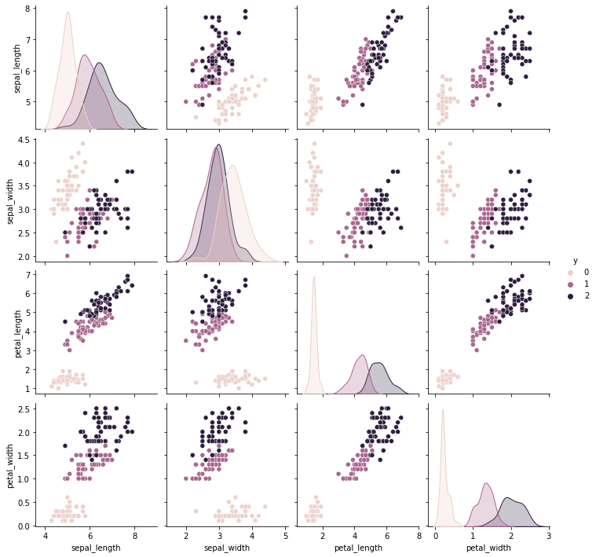

```python
# 0,1,2인 꽃들의 너비, 길이를 확인해 보자
sns.pairplot(iris_new, hue = 'y')
```

## model 만들기

- DecisionTreeClassifier 사용
- train data 만을 학습하고 예측했을때의 결과와 test data를 이용해 예측했을때의 차이를 알아본다

```python
from sklearn.tree import DecisionTreeClassifier
from sklearn.metrics import accuracy_score
```

```python
iris=load_iris()
dt_clf = DecisionTreeClassifier()
dt_clf.fit(iris_x, iris_y)

iris_pred = dt_clf.predict(iris_x)
print('accuracy = ' , accuracy_score(iris_y, iris_pred))

#정확도가 1.0나오는 이유는?
```

```
accuracy =  1.0
```

## train test 분리하기

```python
from sklearn.model_selection import train_test_split
```

```python
X_train, X_test, y_train, y_test = train_test_split(iris_x, iris_y, test_size=0.3, random_state=121)
```

```python
print(len(X_train), len(X_test))
print(len(y_train), len(y_test))
```

```
105 45
105 45
```

## 분리한 데이터로 학습시키고 정확도 구하기

```python
dt_clf.fit(X_train, y_train)
pred = dt_clf.predict(X_test)
print('accuracy = ' , accuracy_score(y_test, pred))
```

```
accuracy =  0.9555555555555556
```

## 과적합(Overfitting)이 될 수 있는 데이터를 검증하기 위한 방법

- 과적합 : 자료의 양이 적을 때 많이 나타난다. 자료가 적다보니 편양된 데이터로 평가하게 되어 다른 데이터로 수행시 성능이 떨어질 수 있다.
- K폴드 교차 검증 : 데이터를 K등분 해 각 세트에 학습,검증을 반복수행하는 방법

```python
from sklearn.model_selection import KFold
```

```python
# 5개로 분리하기로 하자
kfold = KFold(n_splits=5)


#split()으로 변환된 인덱스를 이용해 학습용, 검증용 테스트 데이터 추출
for train_index, test_index in kfold.split(iris_x):
    X_train, X_test = iris_x[train_index], iris_x[test_index]
    y_train, y_test = iris_y[train_index], iris_y[test_index]
print(len(X_train), len(X_test))
print(len(y_train), len(y_test))
```

```
120 30
120 30
```

```python
# 5개로 분리하기로 하자
kfold = KFold(n_splits=5)

n_iter =0  #횟수 출력을 위한 변수
cv_accuracy=[]  # 교차검증때 마다 정확도 저장하기 위한 리스트

#split()으로 변환된 인덱스를 이용해 학습용, 검증용 테스트 데이터 추출
for train_index, test_index in kfold.split(iris_x):
    X_train, X_test = iris_x[train_index], iris_x[test_index]
    y_train, y_test = iris_y[train_index], iris_y[test_index]

    #학습 및 예측
    dt_clf.fit(X_train, y_train)
    pred=dt_clf.predict(X_test)
    n_iter+=1

    acc = np.round(accuracy_score(y_test,pred),4)
    print('%d 교차 검증 정확도 : %.2f \n' % (n_iter, acc))
    cv_accuracy.append(acc)
print('평균 검증 정확도 : %.2f' % np.mean(cv_accuracy))
```

```
1 교차 검증 정확도 : 1.00

2 교차 검증 정확도 : 0.97

3 교차 검증 정확도 : 0.87

4 교차 검증 정확도 : 0.93

5 교차 검증 정확도 : 0.77

평균 검증 정확도 : 0.91
```

## cross_val_score() 함수

- K교차검증의을 위해 for문에서 반복작업해야 하는 것을 좀더 편리하게 해주는 sklean의 API

```python
from sklearn.model_selection import cross_val_score

# 성능지표는 정확도를 알아보고, 교차검증 세튼는 5개로 해 본다
score = cross_val_score(dt_clf, iris_x, iris_y, scoring='accuracy', cv = 5)
print('정확도 : ', np.round(score, 4))
print('평균 검증 정확도 : ', np.round(np.mean(score),4))
```

```
정확도 :  [0.9667 0.9667 0.9    0.9667 1.    ]
평균 검증 정확도 :  0.96
```

## plot_tree() 확인 하기

- iris_x, iris_y는 리스트 구조이므로 열이름이 없어 iris_new를 이용한다.

```python
iris_new
```

|  | sepal_length | sepal_width | petal_length | petal_width | y |
| --- | --- | --- | --- | --- | --- |
| 0 | 5.1 | 3.5 | 1.4 | 0.2 | 0 |
| 1 | 4.9 | 3.0 | 1.4 | 0.2 | 0 |
| 2 | 4.7 | 3.2 | 1.3 | 0.2 | 0 |
| 3 | 4.6 | 3.1 | 1.5 | 0.2 | 0 |
| 4 | 5.0 | 3.6 | 1.4 | 0.2 | 0 |
| ... | ... | ... | ... | ... | ... |
| 145 | 6.7 | 3.0 | 5.2 | 2.3 | 2 |
| 146 | 6.3 | 2.5 | 5.0 | 1.9 | 2 |
| 147 | 6.5 | 3.0 | 5.2 | 2.0 | 2 |
| 148 | 6.2 | 3.4 | 5.4 | 2.3 | 2 |
| 149 | 5.9 | 3.0 | 5.1 | 1.8 | 2 |

150 rows × 5 columns

```python
from sklearn import tree
tree_clf = tree.DecisionTreeClassifier(random_state=100, max_depth = 3)
tree_x = iris_new.drop(columns = 'y')
tree_y = iris_new['y']

tree_model = tree_clf.fit(X = tree_x, y = tree_y)
```

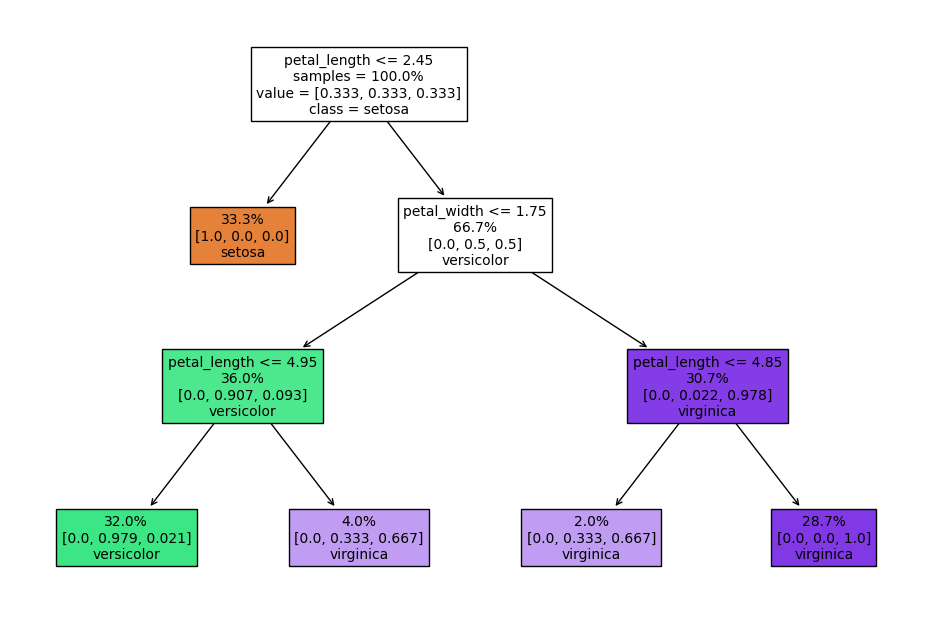

```python
import matplotlib.pyplot as plt
plt.rcParams.update({'figure.figsize' : [12,8], 'figure.dpi' : '100'})
tree.plot_tree(tree_model,
              feature_names=tree_x.columns,
              class_names=['setosa', 'versicolor', 'virginica'],
              proportion = True,
              filled = True,
              impurity = False,
              label = 'root',
              fontsize = 10);
```